# 20250923-IndividualProject01-DaoDang-003245480

2025-09-23

# 1. Executive summary

This report explores how Supi Supermarket can maximize profitability during the holiday season by designing a targeted Gold Membership campaign. Relying on transaction and demographic data, and guided by segmentation and positioning frameworks, the analysis reveals Supi’s most profitable customer groups and the strategic actions needed to convert insights into growth.

On the other hand, “Light” customers: At Risk, Needs Attention make up the largest share of the customer pool (over 35%) but contribute little to revenue. Many are younger, lower in income, and digitally active, making them vulnerable to Lidl and Tokmanni’s price-driven model.

To address these dynamics, this report recommends a tiered membership strategy, personalized communication (in phone call, POSM and digital touch-points) by segment, and sharper positioning of Supi’s existing premium strengths. By pairing exclusivity with affordability, Supi can both grow loyalty among its best customers and defend against market share decrease at the lower end.

# 2. Introduction

Supi Supermarket is one of Finland’s leading grocery retailers, competing directly with SOK, Kesko, Lidl, Alko, and Tokmanni. Operating in a market defined by strong loyalty programs and intense price competition, Supi faces ascending pressure as consumers grow more cost-sensitive under economic downturn. In this environment, sustaining customer relationships is not just advantageous but essential.

This report aims to:

- Profile Supi’s customer base using demographic, behavioral, and value segmentation.
- Identify the customer groups most likely to respond to the Gold Membership campaign.
- Recommend actionable strategies across product, pricing, and communication to strengthen loyalty and profitability.

# 3. Industry analysis

Finland’s grocery market is being reshaped by two opposing forces: rising consumer price sensitivity and intensifying loyalty ecosystems. Lidl has positioned itself as the go-to for low-cost essentials with private-label dominance, while SOK and Kesko strengthen ties with expanded card-based loyalty programs. Tokmanni leverages its variety retail model to capture value-conscious shoppers. (SOK’s S-Etukortti, Kesko’s K-Plussa).

In the context of these competitive pressures, Supi’s opportunity lies in deepening engagement with its most profitable customers. Industry-wide trends show that consumers are now more selective about recurring memberships, but when loyalty programs connect emotionally and deliver tangible value, they remain highly resilient.

# 4. Methods

The analysis combined descriptive statistics with marketing models to create a rounded picture of Supi’s customer base. The applied methods are as following:

- Segmentation Matrix (2x2): Categorized customers by current value (total spend) and potential value (income).
- RFM Analysis: Identified Champions, Loyal Customers, Potential Loyalists, At Risk, and Need Attention segments.
- Demographic profiling: Age, marital status, family status.
- Behavioral profiling: Distribution channel preferences (store, catalog, online), category spending, complaint patterns.
- Correlation analysis: Explored links between income, spending, RFM, and complaints.

These findings were then interpreted using the STP framework and the 4Ps of marketing to guide practical recommendations.

# 5. Key findings

## 5.1 Inspect the data structure

```r
# Load the packages
library(tidyverse)
library(scales)
```

```r
library(corrplot)
#Import data set
supi <- read.csv ("supiforgraphs.csv", header = TRUE, sep = ",")

# Inspect data
str(supi)
```

```
## 'data.frame':    1500 obs. of  31 variables:
##  $ ID                 : int  5524 2174 4141 6182 5324 7446 965 6177 4855 5899 ...
##  $ Year_Birth         : int  1957 1954 1965 1984 1981 1967 1971 1985 1974 1950 ...
##  $ Education          : chr  "Graduation" "Graduation" "Graduation" "Graduation" ...
##  $ Marital_Status     : chr  "Single" "Single" "Together" "Together" ...
##  $ Income             : int  58138 46344 71613 26646 58293 62513 55635 33454 30351 5648 ...
##  $ Kidhome            : int  0 1 0 1 1 0 0 1 1 1 ...
##  $ Teenhome           : int  0 1 0 0 0 1 1 0 0 1 ...
##  $ Dt_Customer        : chr  "04/09/2012" "08/03/2014" "21/08/2013" "10/02/2014" ...
##  $ Recency            : int  58 38 26 26 94 16 34 32 19 68 ...
##  $ MntWines           : int  635 11 426 11 173 520 235 76 14 28 ...
##  $ MntFruits          : int  88 1 49 4 43 42 65 10 0 0 ...
##  $ MntMeatProducts    : int  546 6 127 20 118 98 164 56 24 6 ...
##  $ MntFishProducts    : int  172 2 111 10 46 0 50 3 3 1 ...
##  $ MntSweetProducts   : int  88 1 21 3 27 42 49 1 3 1 ...
```

[output cut: 17 more lines]

```r
head(supi)
```

```
##     ID Year_Birth  Education Marital_Status Income Kidhome Teenhome Dt_Customer
## 1 5524       1957 Graduation         Single  58138       0        0  04/09/2012
## 2 2174       1954 Graduation         Single  46344       1        1  08/03/2014
## 3 4141       1965 Graduation       Together  71613       0        0  21/08/2013
## 4 6182       1984 Graduation       Together  26646       1        0  10/02/2014
## 5 5324       1981        PhD        Married  58293       1        0  19/01/2014
## 6 7446       1967     Master       Together  62513       0        1  09/09/2013
##   Recency MntWines MntFruits MntMeatProducts MntFishProducts MntSweetProducts
## 1      58      635        88             546             172               88
## 2      38       11         1               6               2                1
## 3      26      426        49             127             111               21
## 4      26       11         4              20              10                3
## 5      94      173        43             118              46               27
## 6      16      520        42              98               0               42
##   MntGoldProds NumDealsPurchases NumWebPurchases NumCatalogPurchases
```

[output cut: 20 more lines]

```r
summarise(supi)
```

```
## data frame with 0 columns and 1 row
```

**First observations**

- We have 31 variables which can be converted into valuable insight about demographics and buying behavior if the patterns are visualized.
- The RFM Category (Champions, At Risk, etc.) is the most important variable. It is the master classification used to segment customers by value and link all other data points together.
- Create new variable AgeGroup to convert continuous data (age) into simple, clear segments that are easy to visualize and target with specific marketing actions.

## 5.2 Visualize customer segmentation matrix

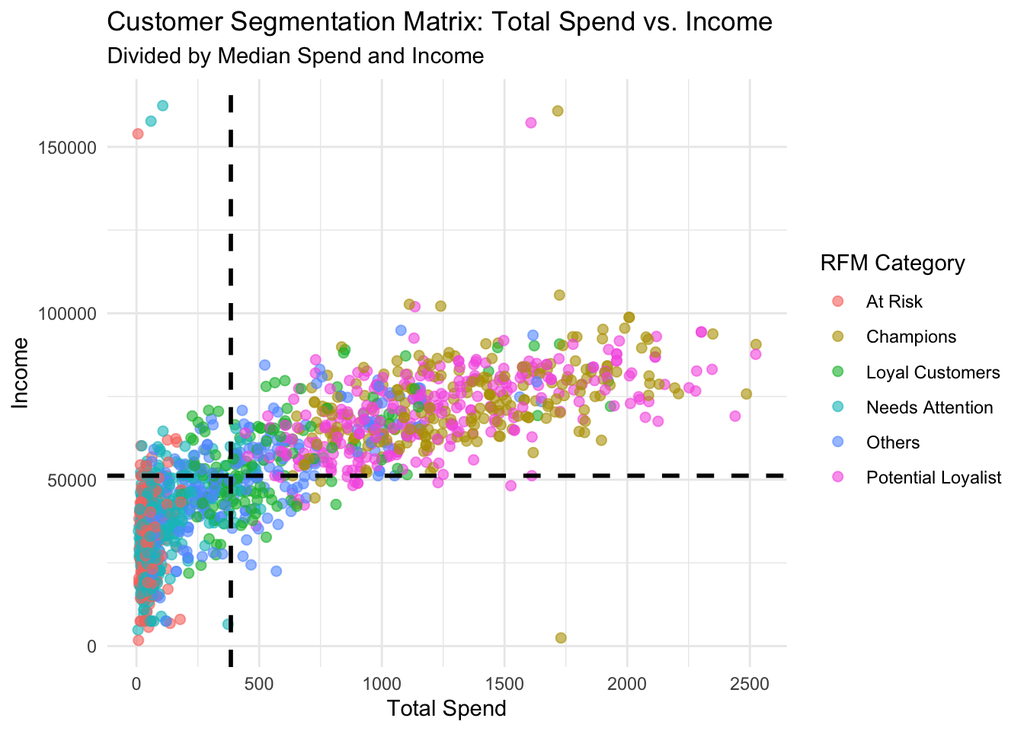

```r
# Define thresholds
median_spend <- median(supi$TotalSpend, na.rm = TRUE)
median_income <- median (supi$Income, na.rm = TRUE)

# Create the scatter plot for the 2x2 segmentation matrix
ggplot(supi, aes(x = TotalSpend, y = Income, color = RFM_Category)) +
  geom_point(alpha = 0.6, size = 2) +
  geom_vline(xintercept = median_spend, linetype = "dashed", color = "black", size = 1) +
  geom_hline(yintercept = median_income, linetype = "dashed", color = "black", size = 1) +
  labs(
    title = "Customer Segmentation Matrix: Total Spend vs. Income",
    subtitle = "Divided by Median Spend and Income",
    x = "Total Spend",
    y = "Income",
    color = "RFM Category"
  ) +
  theme_minimal()
```

## 5.3 Purchasing power statistics

```r
RFM_summary <- supi %>%
  group_by (RFM_Category) %>%
  summarise(
    Count = n(),
    Avg_Age = round(mean(Age, na.rm = TRUE), 1),
    Avg_Income = round(mean(Income, na.rm = TRUE), 0),
    Avg_Spend = round(mean(TotalSpend, na.rm = TRUE), 1)
  ) %>%
  mutate(Percent = round(Count / sum(Count) * 100, 1)) %>%
mutate(RFM_Category = fct_reorder(RFM_Category, Count))

print(RFM_summary)
```

```
## # A tibble: 6 × 6
##   RFM_Category       Count Avg_Age Avg_Income Avg_Spend Percent
##   <fct>              <int>   <dbl>      <dbl>     <dbl>   <dbl>
## 1 At Risk              233    52.6      33145      53.1    15.5
## 2 Champions            230    57.1      73328    1346.     15.3
## 3 Loyal Customers      161    58.2      55936     565      10.7
## 4 Needs Attention      353    54.1      35402     100.     23.5
## 5 Others               232    57.9      49697     451.     15.5
## 6 Potential Loyalist   291    58.8      70379    1217.     19.4
```

## 5.4 Visualize to highlight wthen pool distribution

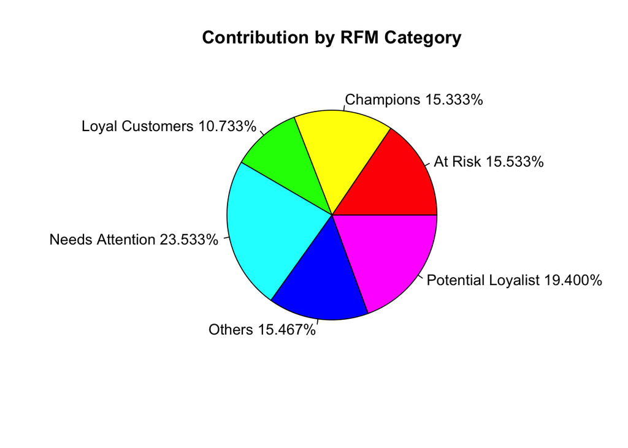

```r
library(scales)
# Create slices and labels
slices2 <- RFM_summary$Count
labels2 <- RFM_summary$RFM_Category
pct2 <- slices2 / sum(slices2)
labels2 <- paste0(labels2, " ", percent (pct2))

# Create the pie chart
pie(slices2,
    labels = labels2,
    col = rainbow(length(labels2)),
    main = "Contribution by RFM Category")
```

**Observations for 5.2, 5.3 & 5.4**

In the matrix diagram, x-axis is total spending and y-axis is income. The segmentation reveals four distinct quadrants:

- Stars (Champions, Loyal Customers, Potential Loyalists): High income and high spend. They represent the revenue backbone of Supi, especially Champions (~15% of customers) whose monthly spend averages 1,300 euros.
- Disengaged/New: Customers with potential (high income or high spend) but not both. One notable out-lier spends nearly 2,000 euros/month despite modest income worth deeper behavioral investigation.
- Light (At Risk, Needs Attention): Numerous (over 35% combined) but low in income and spend. For example, “Need Attention” is the single largest segment at 23.5% of the base, with average age 54 and average monthly spend below 300 euros.

The data makes the trade-off explicit: Supi’s largest customer pool contributes the least, while its smaller, older premium segments drive profitability.

## 5.5 Customer profiling

5.5.1 Visualize customer demographic dynamics (exclude “At Risk” and “Others”)

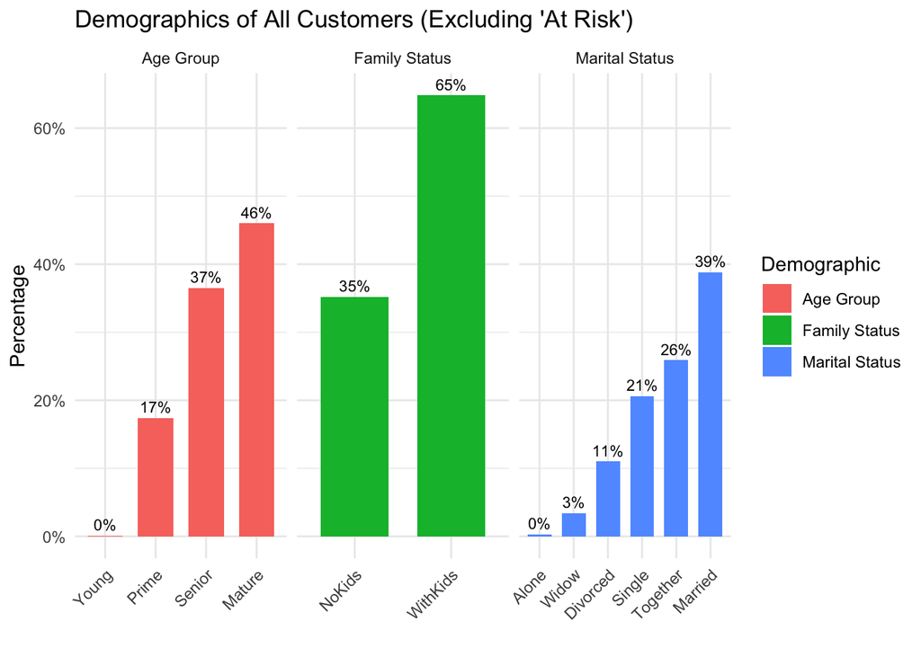

```r
# Create AgeGroup variable
supi <- supi %>%
  mutate (AgeGroup = case_when(
    Age < 30 ~ "Young",
    Age >= 30 & Age <= 45 ~ "Prime",
    Age >= 46 & Age <= 60 ~ "Mature",
    TRUE ~ "Senior"))

# Filter out the "At Risk" and "Others" categories
customers_filtered <- supi %>%
  filter(!RFM_Category %in% c("At Risk", "Others"))

# Summarize the contribution (%) for each demographic attribute
age_summary <- customers_filtered %>%
  group_by(Attribute = AgeGroup) %>%
  summarise(Count = n()) %>%
  mutate(Category = "Age Group",
         Percent = Count / sum(Count) * 100)

has_kids_summary <- customers_filtered %>%
  group_by(Attribute = Has_Kids) %>%
  summarise(Count = n()) %>%
  mutate(Category = "Family Status",
         Percent = Count / sum(Count) * 100)

marital_status_summary <- customers_filtered %>%
  group_by(Attribute = Marital_Status) %>%
  summarise(Count = n()) %>%
  mutate(Category = "Marital Status",
         Percent = Count / sum(Count) * 100)

# Combine the three summary tables into a single data frame
combined_customers_summary <- bind_rows(age_summary, has_kids_summary, marital_status_summary)

# Reorder the attributes for better visualization
combined_customers_summary <- combined_customers_summary %>%
  mutate(Attribute = fct_reorder(Attribute, Percent))

# Create the faceted bar chart for the filtered group
ggplot(combined_customers_summary, aes(x = Attribute, y = Percent, fill = Category)) +
  geom_bar(stat = "identity", width = 0.7) +
  geom_text(aes(label = paste0(round(Percent), "%")), vjust = -0.5, size = 3) +
  facet_wrap(~ Category, scales = "free_x") +
  labs(
    title = "Demographics of All Customers (Excluding 'At Risk')",
    x = "",
    y = "Percentage",
    fill = "Demographic"
  ) +
  theme_minimal() +
  theme(axis.text.x = element_text(angle = 45, hjust = 1)) +
  scale_y_continuous(labels = scales::percent_format(scale = 1))
```

5.5.2 Visualize where do these segments shop

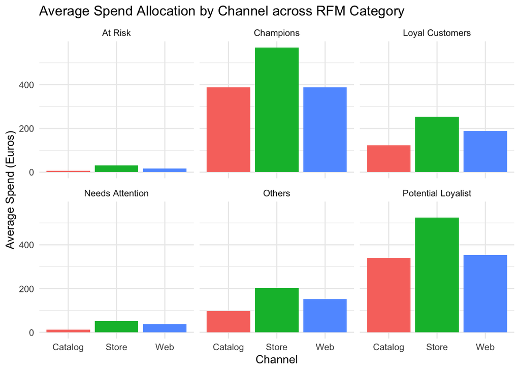

```r
library(scales)
# Allocate spend by dsitribution channel
supi_long <- supi %>%
  select(RFM_Category, NumStorePurchases, NumWebPurchases, NumCatalogPurchases, TotalSpend) %>%
  rowwise() %>%
  mutate(TotalPurchases = NumStorePurchases + NumWebPurchases + NumCatalogPurchases,
         Spend_Store   = ifelse(TotalPurchases > 0, TotalSpend * NumStorePurchases / TotalPurchases, 0),
         Spend_Web     = ifelse(TotalPurchases > 0, TotalSpend * NumWebPurchases / TotalPurchases, 0),
         Spend_Catalog = ifelse(TotalPurchases > 0, TotalSpend * NumCatalogPurchases / TotalPurchases, 0)) %>%
  ungroup() %>%
  select(RFM_Category, Spend_Store, Spend_Web, Spend_Catalog) %>%
  pivot_longer(cols = starts_with("Spend"),
               names_to = "Channel",
               values_to = "Spend") %>%
  mutate(Channel = recode(Channel,
                          "Spend_Store" = "Store",
                          "Spend_Web" = "Web",
                          "Spend_Catalog" = "Catalog"))

# Aggregate
channel_spend <- supi_long %>%
  group_by(RFM_Category, Channel) %>%
  summarise(AvgSpend = mean(Spend, na.rm = TRUE),
            .groups = "drop")

# Create plot facet wrap
ggplot(channel_spend, aes(x = Channel, y = AvgSpend, fill = Channel)) +
  geom_col(show.legend = FALSE)+
  facet_wrap(~ RFM_Category) +
  labs(title = "Average Spend Allocation by Channel across RFM Category",
       x = "Channel",
       y = "Average Spend (Euros)") +
  theme_minimal()
```

5.5.3 Visualize what do they buy by product category

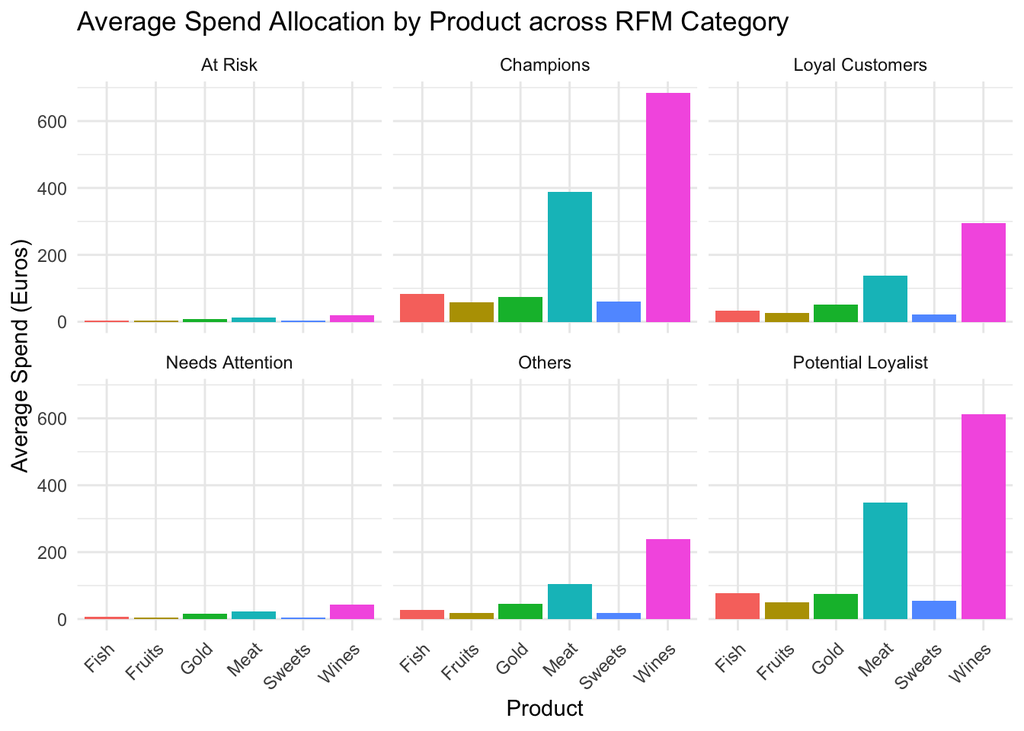

```r
library(scales)
# Allocate spend by product
supi_long_products <- supi %>%
  select(RFM_Category, MntWines, MntFruits, MntMeatProducts, MntFishProducts, MntSweetProducts, MntGoldProds) %>%
  pivot_longer(
    cols = starts_with("Mnt"),
    names_to = "Product",
    values_to = "Spend"
  ) %>%
  mutate(Product = recode(Product,
                          "MntWines" = "Wines",
                          "MntFruits" = "Fruits",
                          "MntMeatProducts" = "Meat",
                          "MntFishProducts" = "Fish",
                          "MntSweetProducts" = "Sweets",
                          "MntGoldProds" = "Gold"))

# Aggregate the average spend for each product by RFM category
product_spend <- supi_long_products %>%
  group_by(RFM_Category, Product) %>%
  summarise(AvgSpend = mean(Spend, na.rm = TRUE),
            .groups = "drop")

# Create plot facet wrap showing the average spend allocation by product
ggplot(product_spend, aes(x = Product, y = AvgSpend, fill = Product)) +
  geom_col(show.legend = FALSE) +
  facet_wrap(~ RFM_Category) +
  labs(
    title = "Average Spend Allocation by Product across RFM Category",
    x = "Product",
    y = "Average Spend (Euros)"
  ) +
  theme_minimal() +
  theme(axis.text.x = element_text(angle = 45, hjust = 1))
```

5.5.4 Visualize web visits frequency by RFM category

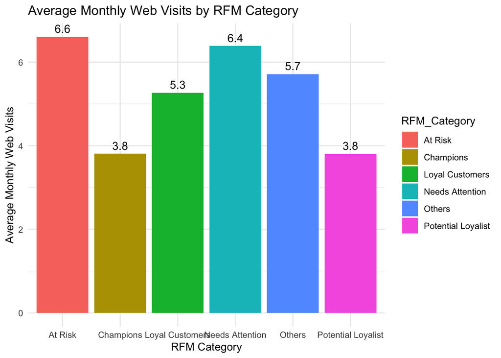

```r
# Calculate the average number of web visits
web_visits_summary <- supi %>%
  group_by(RFM_Category) %>%
  summarise(Avg_WebVisits = mean(NumWebVisitsMonth, na.rm = TRUE))

# Create bar chart
ggplot(web_visits_summary, aes(x = RFM_Category, y = Avg_WebVisits, fill = RFM_Category)) +
  geom_bar(stat = "identity") +
  geom_text(aes(label = round(Avg_WebVisits, 1)), vjust = -0.5, size = 4) +
  labs(
    title = "Average Monthly Web Visits by RFM Category",
    x = "RFM Category",
    y = "Average Monthly Web Visits"
  ) +
  theme_minimal()
```

5.5.5 Visualize spending by product category

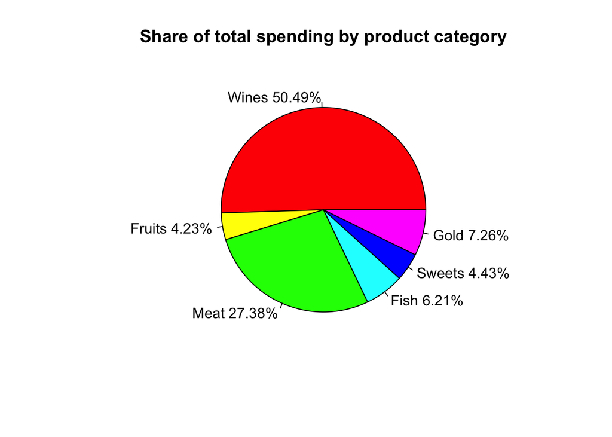

```r
supi_productcategory <- supi %>%
  select(Wines = MntWines,
         Fruits = MntFruits,
         Meat = MntMeatProducts,
         Fish = MntFishProducts,
         Sweets = MntSweetProducts,
         Gold = MntGoldProds) %>%
  summarise(across(everything(), sum)) %>%
  pivot_longer(cols = everything(), names_to = "Category", values_to = "Total")

# Prepare slices and labels
slices <- supi_productcategory$Total
labels <- supi_productcategory$Category
pct <- slices / sum(slices)
labels <- paste0(labels, " ", percent(pct))

# Create plot pie chart
pie(slices,
    labels = labels,
    col = rainbow(length(labels)),
    main = "Share of total spending by product category")
```

5.5.6 Visualize who complain the most

```r
# Summarize the complaint data for all RFM categories
complaint_summary_all <- supi %>%
  group_by(RFM_Category, Complaint = ifelse(Complaint == 1, "Complain", "No Complain")) %>%
  summarise(Count = n(), .groups = "drop_last") %>%
  mutate(Percent = Count / sum(Count) * 100) %>%
  ungroup()

# Print the summary to see the numbers
print(complaint_summary_all)
```

```
## # A tibble: 11 × 4
##    RFM_Category       Complaint   Count Percent
##    <chr>              <chr>       <int>   <dbl>
##  1 At Risk            Complain        4   1.72
##  2 At Risk            No Complain   229  98.3
##  3 Champions          No Complain   230 100
##  4 Loyal Customers    Complain        3   1.86
##  5 Loyal Customers    No Complain   158  98.1
##  6 Needs Attention    Complain        4   1.13
##  7 Needs Attention    No Complain   349  98.9
##  8 Others             Complain        2   0.862
##  9 Others             No Complain   230  99.1
## 10 Potential Loyalist Complain        3   1.03
## 11 Potential Loyalist No Complain   288  99.0
```

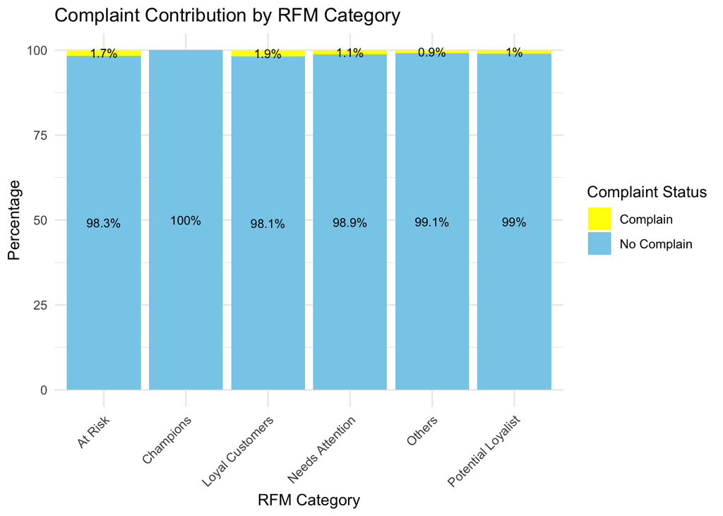

```r
# Visualize the numbers
ggplot(complaint_summary_all, aes(x = RFM_Category, y = Percent, fill = Complaint)) +
  geom_bar(stat = "identity", position = "stack") +
  geom_text(aes(label = paste0(round(Percent, 1), "%")),
            position = position_stack(vjust = 0.5), size = 3) +
  labs(
    title = "Complaint Contribution by RFM Category",
    x = "RFM Category",
    y = "Percentage",
    fill = "Complaint Status"
  ) +
  scale_fill_manual(values = c("Complain" = "Yellow", "No Complain" = "Skyblue")) +
  theme_minimal() +
  theme(axis.text.x = element_text(angle = 45, hjust = 1))
```

**Observations for 5.5 - Customer Profiling**

- *Champions*

Champions are the top revenue drivers. This 15% segment reports the highest income (73K euros) and spends the most (1.3K euro on average). They are typically older, married adults with no children and are traditional shoppers as they prefer in-store purchases and are generally low web visitors. Their loyalty is focused on luxury: wine and meat, spending dramatically more on these key categories. Most critically, they never complain. Focus: high-touch experience, exclusive product access, and effortless service.

- *Loyal Customers*

This 11% segment shops often, but their loyalty requires effort. While they are frequent purchasers, their spending is only average (~0.5K euro on average), suggesting they are regular but budget-conscious buyers. The majority of these customers are older and married without children. They are highly digital, visiting the website more often than any other high-value segment. Critically, they also have the highest complaint rate (1.9%). Their high engagement means they demand high standards. Focus: prioritize exceptional customer service to keep their frequent buying cycle intact.

- *Needs Attention & At Risk*

These groups are risk segments as they are generally younger, have lower income, and don’t spend much. Their most defining characteristic is very high web activity, visiting the website over six times per month. This suggests they are actively comparison shopping or looking for deals rather than committing to purchases. The majority of them shop across both in-store and online. They are also more likely to complain (over 1%). Focus: targeted offers and clear value messaging to convert their high engagement into committed spending before they disappear.

## 5.6 Correlation coefficients between Spending, RFM Score, Income and Complaint

```r
# Filter and select the variables for correlation
correlation <- supi %>%
  select(TotalSpend, RFM_Score, Complaint, Income)

# Calculate the correlation matrix
correlation_matrix <- cor(correlation, use = "complete.obs")

# Print the correlation matrix
print("Correlation Matrix:")
```

```
## [1] "Correlation Matrix:"
```

```r
print(correlation_matrix)
```

```
##             TotalSpend   RFM_Score   Complaint      Income
## TotalSpend  1.00000000  0.78502742 -0.04745362  0.79083691
## RFM_Score   0.78502742  1.00000000 -0.03576389  0.70294397
## Complaint  -0.04745362 -0.03576389  1.00000000 -0.03819129
## Income      0.79083691  0.70294397 -0.03819129  1.00000000
```

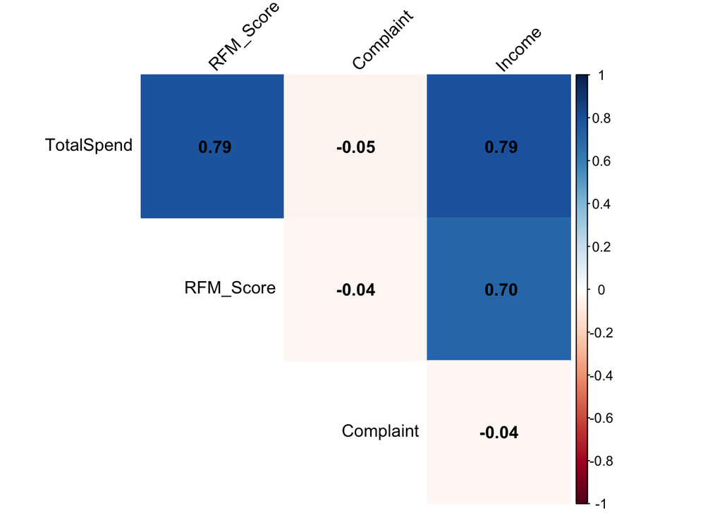

```r
# Visualize the correlation matrix
library (corrplot)
corrplot(correlation_matrix,
         method = "color", # Use a color-based plot
         type = "upper",   # Show only the upper triangle
         addCoef.col = "black", # Add the correlation coefficients as text
         tl.col = "black", # Text label color
         tl.srt = 45,      # Text label rotation
         diag = FALSE)
```

**Observations for 5.6**

Strong correlation

- Income & total spend , total spend & RFM Score scores is 0,79 showing the strongest correlation.
- Income & RFM score is 0.7 also shows strong link between these two variables.

Weak correlation:

- Complaint & other values score is -0.04 showing no linear correlation between whether a customer has complained and their spending, RFM score, or income.

*Conclusion*

The strong correlation between income, RFM score, and total spend confirms that wealthier and more engaged customers drive significant revenue. Interestingly, complaints show no strong link to value, meaning dissatisfaction is spread evenly across groups. This highlights a systemic service challenge rather than a segment-specific one.

# 6. Strategic recommendations

## 4Ps applied

## Promotion: Design tier-based membership

- Position Gold Membership as a premium lifestyle offer for Stars segment, with benefits like limited edition wine, meat and sweet products sold exclusively, wine or/and meat bundles, 20% discounts across all products, and VIP services.
- Offer Silver membership to Disengaged/New customers, focusing on increasing basket size and accelerating their path to the premium Gold tier, like weekly wine & meat pairing at a reasonable discount (10-15%) to leverage their spending preference without giving away the premium 20% Gold discount.
- Introduce a Bronze membership for Light customers, offering everyday savings and accumulative scores to make the effort of shopping with Supi feel more rewarding and highlight the path toward Silver. This can keep them within Supi’s ecosystem and stand out Lidl’s deals.

## Place: Sharpen channel marketing strategy

Older segments remain in-store-oriented, while younger groups go digital. Supi’s campaigns must reflect this dynamic by organizing targeted store events for Stars and high-earning shoppers, combine with engaging digital content for Light customers. A consistent message across all touch-points will strengthen Supi image as a strong supermarket brand.

## Product: Take advantage of product strengths

Wine and meat are Supi’s top-of-mind categories. Position Gold Membership as a gateway to premium experiences with exclusive tasting event, curated bundles for year-end season, or holiday promotions. For Light customers, highlight Supi’s ability to still provide quality essentials at competitive prices with budget packs, etc.

## Customize messaging by segment

- For Champions, emphasize exclusivity *“An exclusive preview, reserved only for our top-tier clients”*
- For Loyal Customers, directly address service quality to rebuild trust *“We heard your feedback: it matters”*
- For Potential Loyalists, craft inspirational messaging tied to lifestyle and tradition, affirm them toward higher-value behavior *“You have built a successful life. Our products are designed to fit that life seamlessly”*
- For Need Attention, focus on affordability and convenience *“Max value, minimum price”*

# 7. Limitations and conclusions

This report analyzes only current Supi customers, which creates a bias by ignoring potential buyers and the wider market. Price recommendations cannot be offered because pricing data was not included in the original dataset. Furthermore, the Complaint data is likely unreliable and too low. I believe actual customer dissatisfaction is higher because many people are hesitant to formally report issues. Finally, the report lacks a complete market view because I was unable to reliably collect current competitor data.